# 2018200954-秦琪瑶-第十一周作业

# 5.1

```r
market <- matrix(c(83,70,45,91,86,15,41,38,10),byrow = T,nrow = 3)
chisq.test(market)
```

```
##
##  Pearson's Chi-squared test
##
## data:  market
## X-squared = 18.651, df = 4, p-value = 0.0009203
```

```r
fisher.test(market,workspace=2e8)
```

```
##
##  Fisher's Exact Test for Count Data
##
## data:  market
## p-value = 0.001019
## alternative hypothesis: two.sided
```

**分析**

两个检验的p值均小于0.05，可以在5%的显著性水平下拒绝原假设，认为不同年龄段的人对各商场的购物倾向性存在差异。

# 5.2

```r
race <- matrix(c(341,405,105,103,11,15),byrow = T,nrow = 2)
chisq.test(race)
```

```
##
##  Pearson's Chi-squared test
##
## data:  race
## X-squared = 79.431, df = 2, p-value < 2.2e-16
```

```r
fisher.test(race,workspace=2e8)
```

```
##
##  Fisher's Exact Test for Count Data
##
## data:  race
## p-value < 2.2e-16
## alternative hypothesis: two.sided
```

**分析**

两个检验的p值均明显小于0.05，可以在5%的显著性水平下拒绝原假设，认为不同种族与所支持政党之间不独立。

# 5.3

```r
feiyan <- matrix(c(6,4,1,19),byrow = T,nrow = 2)
mcnemar.test(feiyan,correct = F)
```

```
##
##  McNemar's Chi-squared test
##
## data:  feiyan
## McNemar's chi-squared = 1.8, df = 1, p-value = 0.1797
```

```r
fisher.test(feiyan)
```

```
##
##  Fisher's Exact Test for Count Data
##
## data:  feiyan
## p-value = 0.002122
## alternative hypothesis: true odds ratio is not equal to 1
## 95 percent confidence interval:
##     2.152514 1362.408171
## sample estimates:
## odds ratio
##    24.2696
```

```r
chisq.test(feiyan)
```

```
##
##  Pearson's Chi-squared test with Yates' continuity correction
##
## data:  feiyan
## X-squared = 8.4084, df = 1, p-value = 0.003735
```

**分析**

McNemar检验的p值大于0.05，不可以在5%的显著性水平下拒绝原假设，即认为某类肺炎患者和以前是否曾经患过该类肺炎之间的不存在继承性关系。但是使用卡方检验和Fisher精确性检验的p值均小于0.05，可以在5%的显著性水平下拒绝原假设，即认为某类肺炎患者和以前是否曾经患过该类肺炎之间的存在继承性关系。

说明McNemar检验只关注部分数据，在本例中失效；Fisher精确性检验的p值小于卡方检验的，本例中部分格子的频数过小，使用卡方检验甚至提示此时不适合使用，说明此时更适合使用Fisher精确性检验。

# 5.4

```r
dianshi <- matrix(c(83,70,45,91,86,15,41,38,10),byrow = T,nrow = 3)
chisq.test(dianshi)
```

```
##
##  Pearson's Chi-squared test
##
## data:  dianshi
## X-squared = 18.651, df = 4, p-value = 0.0009203
```

```r
fisher.test(dianshi,workspace=2e8)
```

```
##
##  Fisher's Exact Test for Count Data
##
## data:  dianshi
## p-value = 0.001019
## alternative hypothesis: two.sided
```

**分析**

两个检验的p值均小于0.05，可以在5%的显著性水平下拒绝原假设，认为不同年龄关注对三种电视节目的关注率存在差异。

# 5.7

```r
a <- matrix(c(43,65,87,77),2)
b <- matrix(c(9,73,15,30),2)
c <- matrix(c(7,18,9,11),2)
dat <- c(a,b,c)
dat <- array(dat,c(2,2,2))
mantelhaen.test(dat)
```

```
##
##  Mantel-Haenszel chi-squared test with continuity correction
##
## data:  dat
## Mantel-Haenszel X-squared = 10.269, df = 1, p-value = 0.001353
## alternative hypothesis: true common odds ratio is not equal to 1
## 95 percent confidence interval:
##  0.3153200 0.7495193
## sample estimates:
## common odds ratio
##         0.4861465
```

**分析**

检验的p值小于0.05，可以在5%的显著性水平下拒绝原假设，认为学生家庭经济情况与其高考成绩之间存在相关性。

# 案例

## (1)绘图

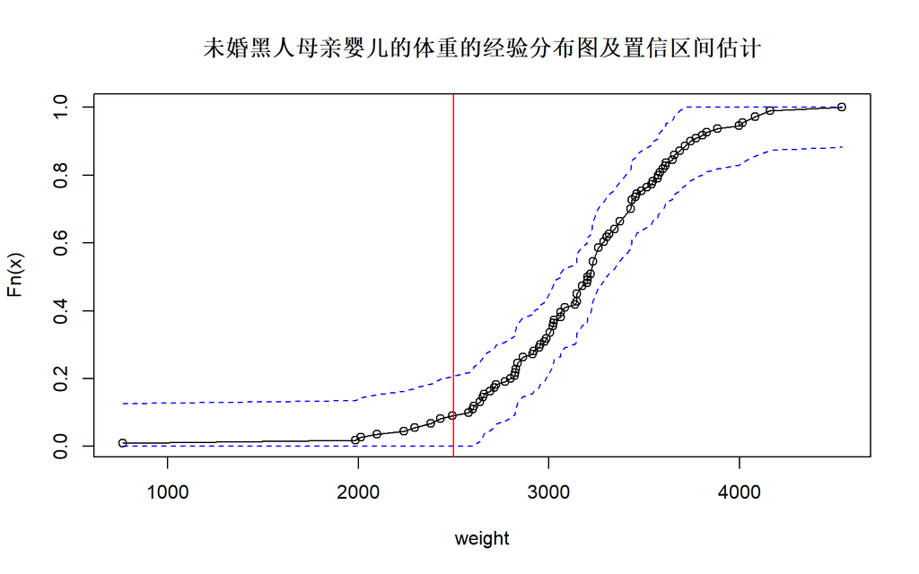

```r
##法一
library(openxlsx)
dat <- read.xlsx("./birth_weight.xlsx")
weight.sort <- sort(dat$weight[(dat$black==1)&(dat$married==0)])
weight.rank <- rank(weight.sort)
n <- length(weight.sort)
weight.ecdf <- weight.rank/n
plot(weight.sort,weight.ecdf,type = 'o',xlab='weight',ylab='Fn(x)',main='未婚黑人母亲婴儿的体重的经验分布图及置信区间估计')
band <- sqrt(log(2/0.1)/(2*n))
lower <- weight.ecdf-band
upper <- weight.ecdf+band
lower[lower<0] <- 0
upper[upper>1] <- 1
lines(weight.sort,lower,lty=2,col='blue')
lines(weight.sort,upper,lty=2,col='blue')
abline(v=2500,col='red')
```

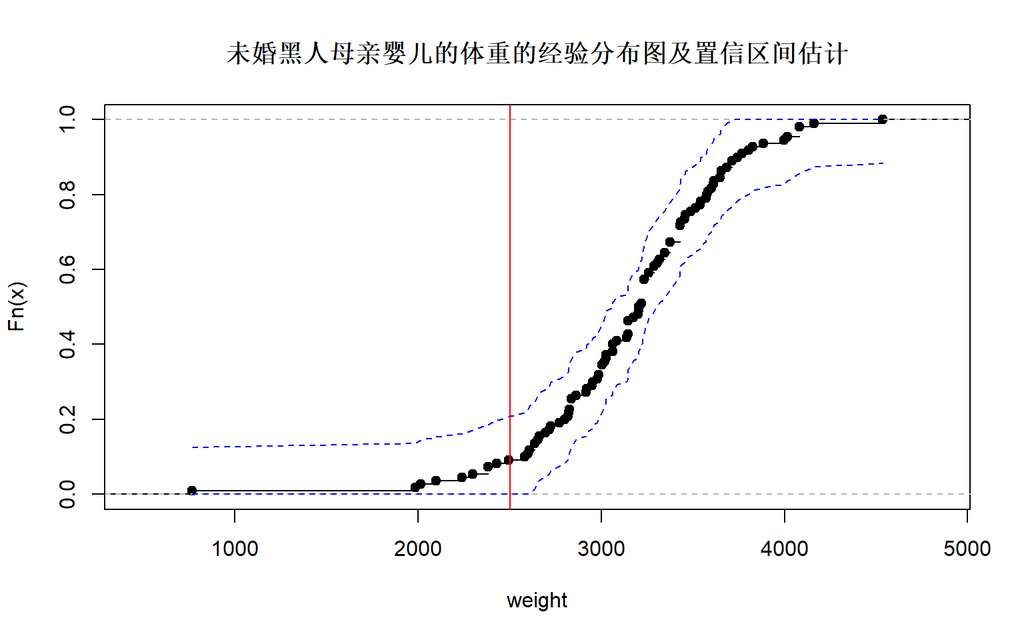

```r
##法二
weight.ecdf.new <- ecdf(weight.sort)
plot(weight.ecdf.new,xlab='weight',ylab='Fn(x)',main='未婚黑人母亲婴儿的体重的经验分布图及置信区间估计')
band <- sqrt(log(2/0.1)/(2*n))
lower <- weight.ecdf-band
upper <- weight.ecdf+band
lower[lower<0] <- 0
upper[upper>1] <- 1
lines(weight.sort,lower,lty=2,col='blue')
lines(weight.sort,upper,lty=2,col='blue')
abline(v=2500,col='red')
```

## (2)泊松回归

```r
library(dplyr)
dat$class <- cut(dat$m.wtgain,breaks = c(-50,-20,-10,0,10,20,55))
dat$lowandblack <- 0
dat$lowandblack[(dat$black==1)&(dat$weight<2500)] <- 1
dat$lowandwhite <- 0
dat$lowandwhite[(dat$black==0)&(dat$weight<2500)] <- 1

dat$white <- 0
dat$white[dat$black==0] <- 1

block <- summarise(group_by(dat,class),black=sum(black),black_low=sum(lowandblack),white_low=sum(lowandwhite),white=sum(white))
head(block)
```

| class | black | black_low | white_low | white |
| --- | --- | --- | --- | --- |
| (-50,-20] | 17 | 2 | 5 | 51 |
| (-20,-10] | 29 | 4 | 9 | 119 |
| (-10,0] | 63 | 6 | 15 | 276 |
| (0,10] | 32 | 1 | 5 | 252 |
| (10,20] | 22 | 2 | 4 | 86 |
| (20,55] | 10 | 1 | 1 | 43 |

```r
dat.new2 <- data.frame(loss_weight=rep(block$class,2),black=c(rep(1,6),rep(0,6)),total=c(block$black,block$white),weight_low=c(block$black_low,block$white_low))

res.weight <- glm(weight_low~loss_weight+black+offset(log(total)),data=dat.new2,family = poisson)

summary(res.weight)
```

```
##
## Call:
## glm(formula = weight_low ~ loss_weight + black + offset(log(total)),
##     family = poisson, data = dat.new2)
##
## Deviance Residuals:
##        1         2         3         4         5         6         7         8
## -0.37678   0.05534  -0.00003  -0.08945   0.10349   0.50079   0.27073  -0.03640
##        9        10        11        12
##  0.00002   0.04146  -0.07058  -0.37314
##
## Coefficients:
##                      Estimate Std. Error z value Pr(>|z|)
## (Intercept)           -2.4460     0.3937  -6.213 5.19e-10 ***
## loss_weight(-20,-10]  -0.1238     0.4693  -0.264   0.7919
## loss_weight(-10,0]    -0.4664     0.4371  -1.067   0.2860
## loss_weight(0,10]     -1.4926     0.5591  -2.670   0.0076 **
## loss_weight(10,20]    -0.5870     0.5566  -1.055   0.2916
## loss_weight(20,55]    -0.9639     0.8021  -1.202   0.2295
## black                  0.5610     0.2984   1.880   0.0601 .
## ---
## Signif. codes:  0 '***' 0.001 '**' 0.01 '*' 0.05 '.' 0.1 ' ' 1
##
## (Dispersion parameter for poisson family taken to be 1)
##
##     Null deviance: 16.95811  on 11  degrees of freedom
## Residual deviance:  0.63508  on  5  degrees of freedom
## AIC: 51.623
##
## Number of Fisher Scoring iterations: 4
```

可以发现，只有母亲的种族、婴儿是否低体重和母亲怀孕期间增加的体重中增重取值在(0，10]为通过t检验的显著变量.

在10%的显著性水平下：

在控制其他变量不变时，母亲孕期增重取值于(0,10]会使婴儿低体重率相比于其他取值更低；

在控制其他变量不变时，母亲是黑人相比于母亲是白人婴儿低体重率显著更高。

## (3)后续讨论题——加入母亲受教育程度和是否已婚

```r
library(plyr)
dat$low <- 0
dat$low[dat$weight<2500] <- 1

#加入是否为高中教育水平
block.new1 <- ddply(dat,.(black,class,ed.hs),summarize,weight_low=sum(low),total=length(weight))
block.new1
```

| black | class | ed.hs | weight_low | total |
| --- | --- | --- | --- | --- |
| 0 | (-50,-20] | 0 | 4 | 29 |
| 0 | (-50,-20] | 1 | 1 | 22 |
| 0 | (-20,-10] | 0 | 8 | 69 |
| 0 | (-20,-10] | 1 | 1 | 50 |
| 0 | (-10,0] | 0 | 9 | 176 |
| 0 | (-10,0] | 1 | 6 | 100 |
| 0 | (0,10] | 0 | 2 | 182 |
| 0 | (0,10] | 1 | 3 | 70 |
| 0 | (10,20] | 0 | 3 | 55 |
| 0 | (10,20] | 1 | 1 | 31 |

[output cut: 14 more lines]

```r
res.weight.new1 <- glm(weight_low~class+black+ed.hs+offset(log(total)),data=block.new1,family = poisson)
summary(res.weight.new1)
```

```
##
## Call:
## glm(formula = weight_low ~ class + black + ed.hs + offset(log(total)),
##     family = poisson, data = block.new1)
##
## Deviance Residuals:
##     Min       1Q   Median       3Q      Max
## -1.4627  -0.5932  -0.1000   0.4651   1.4590
##
## Coefficients:
##                Estimate Std. Error z value Pr(>|z|)
## (Intercept)     -2.3414     0.4082  -5.736 9.67e-09 ***
## class(-20,-10]  -0.1309     0.4693  -0.279  0.78030
## class(-10,0]    -0.4823     0.4375  -1.102  0.27031
## class(0,10]     -1.5259     0.5604  -2.723  0.00647 **
## class(10,20]    -0.6102     0.5571  -1.095  0.27342
## class(20,55]    -0.9879     0.8026  -1.231  0.21835
## black            0.5562     0.2986   1.863  0.06249 .
## ed.hs           -0.2618     0.2926  -0.895  0.37099
## ---
## Signif. codes:  0 '***' 0.001 '**' 0.01 '*' 0.05 '.' 0.1 ' ' 1
##
## (Dispersion parameter for poisson family taken to be 1)
##
##     Null deviance: 30.237  on 23  degrees of freedom
## Residual deviance: 13.089  on 16  degrees of freedom
## AIC: 83.074
##
## Number of Fisher Scoring iterations: 5
```

```r
#加入是否为大学教育水平
block.new2 <- plyr::ddply(dat,.(black,class,ed.col),summarize,weight_low=sum(low),total=length(weight))
block.new2
```

| black | class | ed.col | weight_low | total |
| --- | --- | --- | --- | --- |
| 0 | (-50,-20] | 0 | 4 | 45 |
| 0 | (-50,-20] | 1 | 1 | 6 |
| 0 | (-20,-10] | 0 | 5 | 93 |
| 0 | (-20,-10] | 1 | 4 | 26 |
| 0 | (-10,0] | 0 | 10 | 205 |
| 0 | (-10,0] | 1 | 5 | 71 |
| 0 | (0,10] | 0 | 4 | 173 |
| 0 | (0,10] | 1 | 1 | 79 |
| 0 | (10,20] | 0 | 4 | 64 |
| 0 | (10,20] | 1 | 0 | 22 |

[output cut: 14 more lines]

```r
res.weight.new2 <- glm(weight_low~class+black+ed.col+offset(log(total)),data=block.new2,family = poisson)
summary(res.weight.new2)
```

```
##
## Call:
## glm(formula = weight_low ~ class + black + ed.col + offset(log(total)),
##     family = poisson, data = block.new2)
##
## Deviance Residuals:
##     Min       1Q   Median       3Q      Max
## -1.5528  -0.6077  -0.1227   0.3293   1.0365
##
## Coefficients:
##                Estimate Std. Error z value Pr(>|z|)
## (Intercept)     -2.4734     0.3978  -6.217 5.06e-10 ***
## class(-20,-10]  -0.1366     0.4700  -0.291  0.77129
## class(-10,0]    -0.4852     0.4388  -1.106  0.26882
## class(0,10]     -1.5197     0.5618  -2.705  0.00683 **
## class(10,20]    -0.6018     0.5575  -1.080  0.28036
## class(20,55]    -0.9699     0.8022  -1.209  0.22664
## black            0.5765     0.3001   1.921  0.05470 .
## ed.col           0.1711     0.3212   0.533  0.59429
## ---
## Signif. codes:  0 '***' 0.001 '**' 0.01 '*' 0.05 '.' 0.1 ' ' 1
##
## (Dispersion parameter for poisson family taken to be 1)
##
##     Null deviance: 24.9472  on 23  degrees of freedom
## Residual deviance:  8.3487  on 16  degrees of freedom
## AIC: 74.23
##
## Number of Fisher Scoring iterations: 5
```

```r
#加入是否已婚
block.new3 <- plyr::ddply(dat,.(black,class,married),summarize,weight_low=sum(low),total=length(weight))
block.new3
```

| black | class | married | weight_low | total |
| --- | --- | --- | --- | --- |
| 0 | (-50,-20] | 0 | 1 | 14 |
| 0 | (-50,-20] | 1 | 4 | 37 |
| 0 | (-20,-10] | 0 | 3 | 31 |
| 0 | (-20,-10] | 1 | 6 | 88 |
| 0 | (-10,0] | 0 | 1 | 59 |
| 0 | (-10,0] | 1 | 14 | 217 |
| 0 | (0,10] | 0 | 3 | 58 |
| 0 | (0,10] | 1 | 2 | 194 |
| 0 | (10,20] | 0 | 2 | 23 |
| 0 | (10,20] | 1 | 2 | 63 |

[output cut: 14 more lines]

```r
res.weight.new3 <- glm(weight_low~class+black+married+offset(log(total)),data=block.new3,family = poisson)
summary(res.weight.new3)
```

```
##
## Call:
## glm(formula = weight_low ~ class + black + married + offset(log(total)),
##     family = poisson, data = block.new3)
##
## Deviance Residuals:
##      Min        1Q    Median        3Q       Max
## -1.47643  -0.76109  -0.09068   0.45649   1.42745
##
## Coefficients:
##                Estimate Std. Error z value Pr(>|z|)
## (Intercept)    -2.42576    0.44919  -5.400 6.65e-08 ***
## class(-20,-10] -0.12249    0.46949  -0.261  0.79416
## class(-10,0]   -0.46491    0.43743  -1.063  0.28786
## class(0,10]    -1.49073    0.55952  -2.664  0.00772 **
## class(10,20]   -0.58662    0.55665  -1.054  0.29195
## class(20,55]   -0.96088    0.80282  -1.197  0.23135
## black           0.54950    0.32305   1.701  0.08894 .
## married        -0.02832    0.30447  -0.093  0.92590
## ---
## Signif. codes:  0 '***' 0.001 '**' 0.01 '*' 0.05 '.' 0.1 ' ' 1
##
## (Dispersion parameter for poisson family taken to be 1)
##
##     Null deviance: 30.473  on 23  degrees of freedom
## Residual deviance: 14.142  on 16  degrees of freedom
## AIC: 82.863
##
## Number of Fisher Scoring iterations: 5
```

```r
#三个变量同时加入
block.new4 <- plyr::ddply(dat,.(class,ed.hs,ed.col,black,married),summarize,weight_low=sum(low),total=length(weight))
block.new4
```

| class | ed.hs | ed.col | black | married | weight_low | total |
| --- | --- | --- | --- | --- | --- | --- |
| (-50,-20] | 0 | 0 | 0 | 0 | 1 | 10 |
| (-50,-20] | 0 | 0 | 0 | 1 | 2 | 13 |
| (-50,-20] | 0 | 0 | 1 | 0 | 1 | 6 |
| (-50,-20] | 0 | 0 | 1 | 1 | 0 | 2 |
| (-50,-20] | 0 | 1 | 0 | 1 | 1 | 6 |
| (-50,-20] | 0 | 1 | 1 | 1 | 0 | 2 |
| (-50,-20] | 1 | 0 | 0 | 0 | 0 | 4 |
| (-50,-20] | 1 | 0 | 0 | 1 | 1 | 18 |
| (-50,-20] | 1 | 0 | 1 | 0 | 1 | 6 |
| (-50,-20] | 1 | 0 | 1 | 1 | 0 | 1 |

[output cut: 55 more lines]

```r
res.weight.new4 <- glm(weight_low~class+ed.hs+ed.col+black+married+offset(log(total)),data=block.new4,family = poisson)
summary(res.weight.new4)
```

```
##
## Call:
## glm(formula = weight_low ~ class + ed.hs + ed.col + black + married +
##     offset(log(total)), family = poisson, data = block.new4)
##
## Deviance Residuals:
##     Min       1Q   Median       3Q      Max
## -1.8520  -0.6732  -0.3990   0.4654   2.0219
##
## Coefficients:
##                Estimate Std. Error z value Pr(>|z|)
## (Intercept)    -2.30612    0.46939  -4.913 8.97e-07 ***
## class(-20,-10] -0.13335    0.47008  -0.284  0.77666
## class(-10,0]   -0.48668    0.43887  -1.109  0.26745
## class(0,10]    -1.53181    0.56217  -2.725  0.00643 **
## class(10,20]   -0.61421    0.55756  -1.102  0.27064
## class(20,55]   -0.97999    0.80318  -1.220  0.22242
## ed.hs          -0.23960    0.31531  -0.760  0.44732
## ed.col          0.09323    0.36233   0.257  0.79694
## black           0.53174    0.32397   1.641  0.10073
## married        -0.08336    0.32097  -0.260  0.79509
## ---
## Signif. codes:  0 '***' 0.001 '**' 0.01 '*' 0.05 '.' 0.1 ' ' 1
##
## (Dispersion parameter for poisson family taken to be 1)
##
##     Null deviance: 68.885  on 64  degrees of freedom
## Residual deviance: 51.634  on 55  degrees of freedom
## AIC: 151.15
##
## Number of Fisher Scoring iterations: 6
```

## (4)后续讨论题——使用对数线性模型

### ①使用glm函数

```r
block.new5 <- ddply(dat,.(class,black),summarize,weight_low=sum(low))
block.new5
```

| class | black | weight_low |
| --- | --- | --- |
| (-50,-20] | 0 | 5 |
| (-50,-20] | 1 | 2 |
| (-20,-10] | 0 | 9 |
| (-20,-10] | 1 | 4 |
| (-10,0] | 0 | 15 |
| (-10,0] | 1 | 6 |
| (0,10] | 0 | 5 |
| (0,10] | 1 | 1 |
| (10,20] | 0 | 4 |
| (10,20] | 1 | 2 |

[output cut: 2 more lines]

```r
mod <- glm(weight_low~class+black,data=block.new5)
summary(mod)
```

```
##
## Call:
## glm(formula = weight_low ~ class + black, data = block.new5)
##
## Deviance Residuals:
##        1         2         3         4         5         6         7         8
## -0.41667   0.41667   0.58333  -0.58333   2.58333  -2.58333   0.08333  -0.08333
##        9        10        11        12
## -0.91667   0.91667  -1.91667   1.91667
##
## Coefficients:
##                Estimate Std. Error t value Pr(>|t|)
## (Intercept)       5.417      1.653   3.277   0.0220 *
## class(-20,-10]    3.000      2.164   1.386   0.2243
## class(-10,0]      7.000      2.164   3.235   0.0231 *
## class(0,10]      -0.500      2.164  -0.231   0.8264
## class(10,20]     -0.500      2.164  -0.231   0.8264
## class(20,55]     -2.500      2.164  -1.155   0.3002
## black            -3.833      1.249  -3.068   0.0278 *
## ---
## Signif. codes:  0 '***' 0.001 '**' 0.01 '*' 0.05 '.' 0.1 ' ' 1
##
## (Dispersion parameter for gaussian family taken to be 4.683333)
##
##     Null deviance: 182.917  on 11  degrees of freedom
## Residual deviance:  23.417  on  5  degrees of freedom
## AIC: 58.077
##
## Number of Fisher Scoring iterations: 2
```

**分析**

可以发现与泊松回归相比，显著变量发生变化。

在10%的显著性水平下：

在控制其他变量不变时，母亲孕期增重取值于(-10,0]的低体重婴儿更多；

在控制其他变量不变时，母亲是黑人相比于母亲是白人低体重婴儿更少。

### ②使用loglm函数

```r
##使用loglm

library(MASS)
library(plyr)
model <- loglm(weight_low~class*black,data=block.new5)
coef(model)
```

```
## $`(Intercept)`
## [1] 1.172899
##
## $class
##   (-50,-20]   (-20,-10]     (-10,0]      (0,10]     (10,20]     (20,55]
## -0.02160688  0.61886004  1.07700541 -0.36818047 -0.13317866 -1.17289943
##
## $black
##          0          1
##  0.4121747 -0.4121747
##
## $class.black
##            black
## class                  0            1
##   (-50,-20]  0.045970635 -0.045970635
##   (-20,-10] -0.006709623  0.006709623
##   (-10,0]    0.045970635 -0.045970635
##   (0,10]     0.392544225 -0.392544225
##   (10,20]   -0.065601141  0.065601141
##   (20,55]   -0.412174731  0.412174731
```

```r
block.new6 <- ddply(dat,.(class,black,low),summarize,total=length(low))
block.new6
```

| class | black | low | total |
| --- | --- | --- | --- |
| (-50,-20] | 0 | 0 | 46 |
| (-50,-20] | 0 | 1 | 5 |
| (-50,-20] | 1 | 0 | 15 |
| (-50,-20] | 1 | 1 | 2 |
| (-20,-10] | 0 | 0 | 110 |
| (-20,-10] | 0 | 1 | 9 |
| (-20,-10] | 1 | 0 | 25 |
| (-20,-10] | 1 | 1 | 4 |
| (-10,0] | 0 | 0 | 261 |
| (-10,0] | 0 | 1 | 15 |

[output cut: 14 more lines]

```r
model <- loglm(total~class*black*low,data=block.new6)
coef(model)
```

```
## $`(Intercept)`
## [1] 2.517464
##
## $class
##  (-50,-20]  (-20,-10]    (-10,0]     (0,10]    (10,20]    (20,55]
## -0.3076447  0.3582549  1.0093814  0.1207395 -0.1469906 -1.0337404
##
## $black
##          0          1
##  0.5873581 -0.5873581
##
## $low
##         0         1
##  1.344564 -1.344564
##
## $class.black
##            black
## class                 0           1
##   (-50,-20] -0.07813763  0.07813763
##   (-20,-10] -0.01422443  0.01422443
##   (-10,0]    0.02208185 -0.02208185
##   (0,10]     0.33385164 -0.33385164
##   (10,20]   -0.06132458  0.06132458
##   (20,55]   -0.20224686  0.20224686
##
## $class.low
##            low
## class                 0           1
##   (-50,-20] -0.28603786  0.28603786
##   (-20,-10] -0.26060517  0.26060517
##   (-10,0]   -0.06762398  0.06762398
##   (0,10]     0.48891993 -0.48891993
##   (10,20]   -0.01381199  0.01381199
##   (20,55]    0.13915907 -0.13915907
##
## $black.low
##      low
## black          0          1
##     0  0.1751834 -0.1751834
##     1 -0.1751834  0.1751834
```

[output cut: 8 more lines]

```
##   (-10,0]   -0.023888783  0.023888783
##   (0,10]    -0.058692580  0.058692580
##   (10,20]    0.004276563 -0.004276563
##   (20,55]    0.209927875 -0.209927875
##
## , , low = 1
##
##            black
## class                  0            1
##   (-50,-20]  0.124108270 -0.124108270
##   (-20,-10]  0.007514804 -0.007514804
##   (-10,0]    0.023888783 -0.023888783
##   (0,10]     0.058692580 -0.058692580
##   (10,20]   -0.004276563  0.004276563
##   (20,55]   -0.209927875  0.209927875
```

## (5)独立性检验

```r
f <- function(x,alpha){
  df=x$df
  lrt=x$lrt
  p.lrt=1-pchisq(x$lrt,x$df)
  Q=x$pear
  p.pear=1-pchisq(x$pear,x$df)
  if(p.lrt<alpha|p.pear<alpha){conclusion="不独立"}else{conclusion="独立"}
  list(p.lrt=p.lrt,p.pear=p.pear,conclusion=conclusion)
}
A <- matrix(c(2,15,5,46),nrow = 2,byrow = T)
B <- matrix(c(4,25,9,110),nrow = 2,byrow = T)
C <- matrix(c(6,63,15,261),nrow = 2,byrow = T)
D <- matrix(c(1,31,5,247),nrow = 2,byrow = T)
E <- matrix(c(2,20,4,82),nrow = 2,byrow = T)
G <- matrix(c(1,9,1,42),nrow = 2,byrow = T)
a <- array(c(A,B,C,D,E,G),dim=c(2,2,6))
test1<- loglin(a,list(1,2,3),para=T,fit = T)
```

```
## 2 iterations: deviation 2.273737e-13
```

```r
f(test1,0.05)
```

```
## $p.lrt
## [1] 0.01384135
##
## $p.pear
## [1] 0.01115426
##
## $conclusion
## [1] "不独立"
```

母亲的种族、婴儿是否低体重和母亲怀孕期间增加的体重之间存在关联性

```r
test2 <- loglin(a,list(c(1,2),c(1,3)))
```

```
## 2 iterations: deviation 1.136868e-13
```

```r
f(test2,0.05)
```

```
## $p.lrt
## [1] 0.2229169
##
## $p.pear
## [1] 0.2536137
##
## $conclusion
## [1] "独立"
```

在给定母亲种族的条件下，婴儿是否低体重和母亲怀孕期间增加的体重之间独立

```r
test3 <- loglin(a,list(c(1,3),c(2,3)))
```

```
## 2 iterations: deviation 5.684342e-14
```

```r
f(test3,0.05)
```

```
## $p.lrt
## [1] 0.7053357
##
## $p.pear
## [1] 0.627783
##
## $conclusion
## [1] "独立"
```

在给定母亲怀孕期间增加的体重的条件下，婴儿是否低体重和母亲种族之间独立

```r
test4 <- loglin(a,list(c(2,3),c(1,2)))
```

```
## 2 iterations: deviation 7.105427e-15
```

```r
f(test3,0.05)
```

```
## $p.lrt
## [1] 0.7053357
##
## $p.pear
## [1] 0.627783
##
## $conclusion
## [1] "独立"
```

```r
test5 <- loglin(a,list(c(1,2),3))
```

```
## 2 iterations: deviation 5.684342e-14
```

```r
f(test5,0.05)
```

```
## $p.lrt
## [1] 0.03379843
##
## $p.pear
## [1] 0.0518539
##
## $conclusion
## [1] "不独立"
```

```r
test6 <- loglin(a,list(c(1,3),2))
```

```
## 2 iterations: deviation 1.136868e-13
```

```r
f(test6,0.05)
```

```
## $p.lrt
## [1] 0.09409428
##
## $p.pear
## [1] 0.0914166
##
## $conclusion
## [1] "独立"
```

```r
test7 <- loglin(a,list(c(2,3),1))
```

```
## 2 iterations: deviation 5.684342e-14
```

```r
f(test7,0.05)
```

```
## $p.lrt
## [1] 0.1021486
##
## $p.pear
## [1] 0.09852224
##
## $conclusion
## [1] "独立"
```

无法拒绝母亲种族与其他两个因素以及婴儿是否低体重与其他两因素的独立性，但是母亲怀孕期间增加的体重和其他两个因素是存在关联性的。

## (6)利用SAS运行对比结果

**由于R中使用loglm函数无法输出参数估计的检验p值不便于直接比较，因此使用SAS(9.2)进行对数线性模型构建**

### 代码

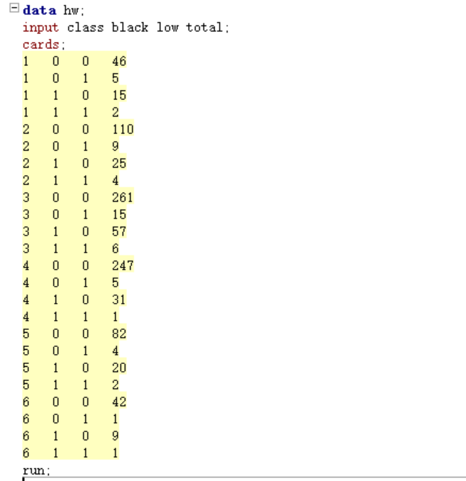

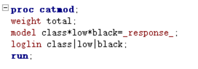

### 运行结果

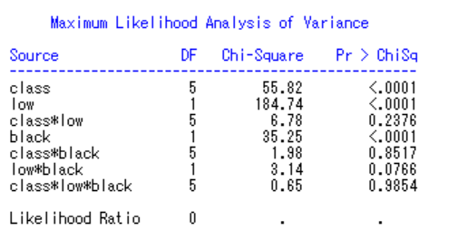

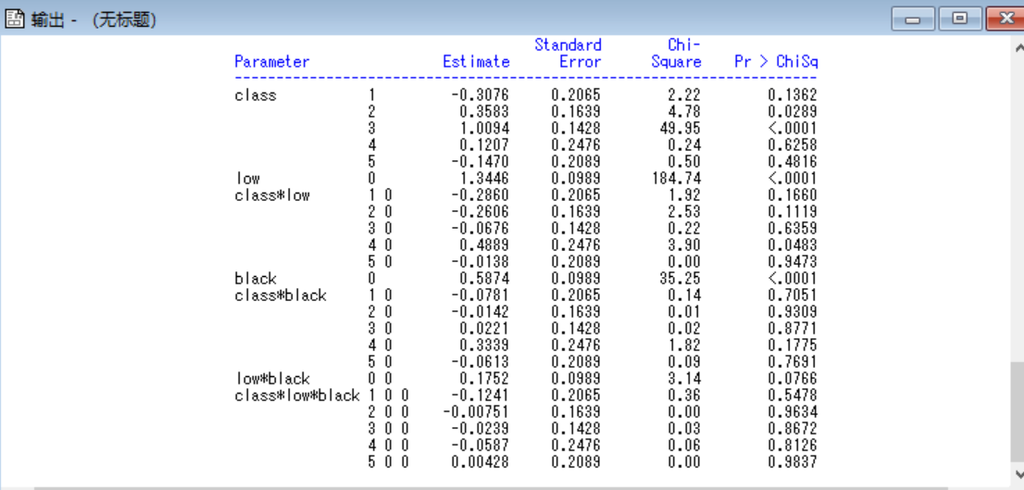